# Chapter 1: Budyko Framework

## Excercise 1.1

In this exercise we will use dataset from sample global watersheds to evaluate the effect of watershed characteristics like slope, elevation and vegetation i.e. (NDVI) on Aridity v/s Evaporative Index relationship.

```r
# Import libraries
library(mapview)      # Spatial map
library(RColorBrewer) # Colors
library(readr)        # Data import
library(ggplot2)      # Scatter plot
library(knitr)

#~~~~ Import watershed dataset from current working directory
watershed_data <- read_csv("watershed_data.csv")
kable(head(watershed_data))
```

| …1 | Latitude | Longitude | HydroSHEDS_ID | Aridity | Evaporative_index | Elevation | Slope | NDVI |
| --- | --- | --- | --- | --- | --- | --- | --- | --- |
| 1 | 42.8583 | 81.4444 | 4050327070 | 0.3145686 | 0.1752921 | 2575.7972 | 17.7475 | 0.313 |
| 2 | -14.3818 | -52.5748 | 6050527670 | 0.0870648 | 0.2693349 | 404.2755 | 1.7378 | 0.646 |
| 3 | 19.4710 | 36.6596 | 1050002290 | 1.0778593 | 0.4383285 | 742.5314 | 8.2235 | 0.091 |
| 4 | 17.3416 | -8.5339 | 1050560730 | 0.4325263 | 0.4050971 | 219.8259 | 0.8326 | 0.136 |
| 5 | 38.2901 | 104.1024 | 4050050850 | 0.5089746 | 0.3919877 | 1481.5513 | 1.7141 | 0.083 |
| 6 | 25.6803 | 88.0289 | 4050960480 | 0.0772554 | 0.1921181 | 127.9712 | 1.9496 | 0.504 |

## Assignment questions

Using the data and references provides, answer the following questions:

**(4 questions, 10 points each)** 1) What is Budyko framework. Comment on its uses and limitations.

2. Evaluate the relationship between the physical watershed characteristics (slope, elevation, vegetation i.e. NDVI) and the Evaporative index.
3. Comment on the impact of different watershed characteristics on the relationship between Aridity Index and Evaporative Index (Hint: think in terms of the fitting parameter omega).
4. Select three watersheds from contrasting locations over the globe and illustrate the hydroclimatic differences in govering the location of the watershed in the Budyko space. Provide details on the locations with maps and HydroSHEDS_ID.

## Sample codes and maps

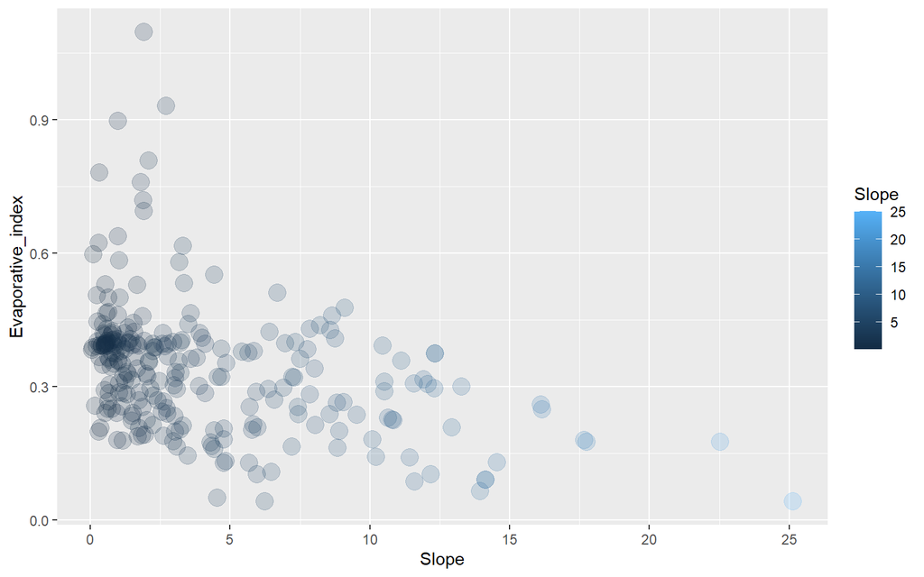

```r
#~~~~ Plotting Slope v/s Evaporative Index
ggplot(watershed_data, aes(x=Slope, y=Evaporative_index)) +
  geom_point(aes(color = Slope), size = 5,alpha = 0.2)
```

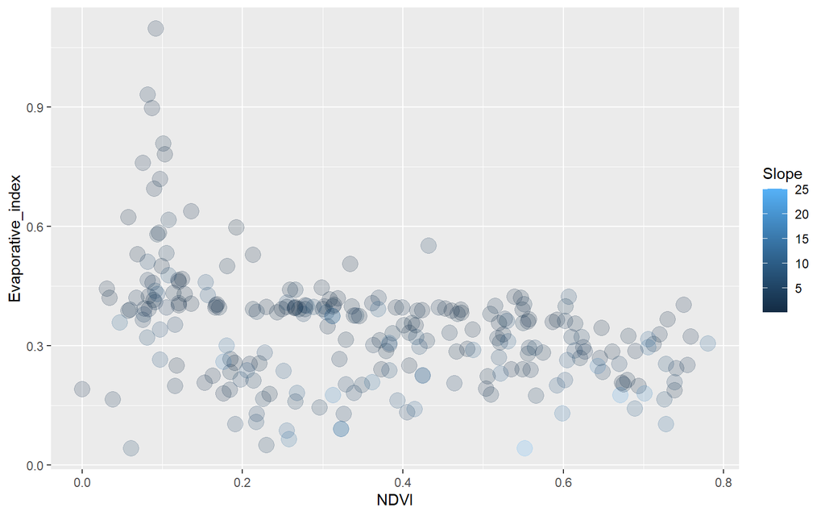

```r
#~~~~ Plotting NDVI v/s Evaporative Index
ggplot(watershed_data, aes(x=NDVI, y=Evaporative_index)) +
  geom_point(aes(color = Slope), size = 5,alpha = 0.2)
```

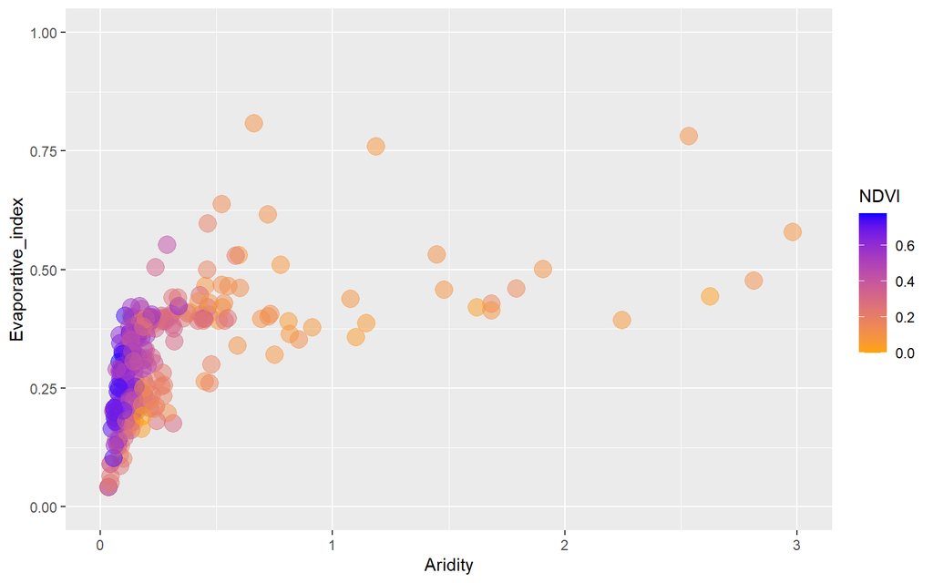

```r
#~~~~ Plotting Aridity v/s Evaporative Index with NDVI
ggplot(watershed_data, aes(x=Aridity, y=Evaporative_index,NDVI)) +
  geom_point(aes(color = NDVI), size = 5,alpha = 0.5) +        # Add points to the plot
  scale_color_gradient(low = "orange", high = "blue")+          # Add colors
  xlim(c(0,3))+                                                 # X-axis limit
  ylim(c(0,1))                                                  # Y-axis limit
```

```r
#~~~~ Spatial plots for Evaporative Index
mapview(watershed_data,  main="Evaporative_index",
        xcol = "Longitude", ycol = "Latitude", zcol  = "Evaporative_index",
        crs = 4269,                              # Coordinate reference system
        grid = FALSE,                            # Turn Grid on or off
        at=seq(0, 1, 0.1),
        col.regions = brewer.pal(11,"Spectral"), # Color
        alpha = 0.5)                             # Transparency
```

[interactive chart not shown]

```r
#~~~~ Spatial plots for NDVI (vegetation index)
mapview(watershed_data, main="NDVI",
        xcol = "Longitude", ycol = "Latitude", zcol  = "NDVI",
        crs = 4269,                              # Coordinate reference system
        grid = FALSE,                            # Turn Grid on or off
        at=seq(0, 1, 0.1),
        col.regions = brewer.pal(11,"Spectral"), # Color
        alpha = 0.5)                             # Transparency
```

[interactive chart not shown]

## Suggested reading

1. Edwards, P.J., Williard, K.W. and Schoonover, J.E., 2015. **Fundamentals of watershed hydrology**.Journal of contemporary water research & education,154(1), pp.3-20.
2. Koppa, A., Alam, S., Miralles, D.G. and Gebremichael, M., 2021. **Budyko‐Based Long‐Term Water and Energy Balance Closure in Global Watersheds From Earth Observations**. Water Resources Research, 57(5), p.e2020WR028658.
3. Li, D., Pan, M., Cong, Z., Zhang, L. and Wood, E., 2013. **Vegetation control on water and energy balance within the Budyko framework**. Water Resources Research, 49(2), pp.969-976.
4. Xu, X., Liu, W., Scanlon, B.R., Zhang, L. and Pan, M., 2013. **Local and global factors controlling water‐energy balances within the Budyko framework**. Geophysical Research Letters, 40(23), pp.6123-6129.

Data source: https://zenodo.org/record/4002795#.Y4lNbijMKUk